# Un Group Data

Ungrouped data woh hota hai jisme har individual value alag alag hoti hai, bina kisi group ya class ke.

```
Marks of 6 students = [56, 72, 64, 64, 90, 72]
```

```python
import pandas as pd
```

```python
pd.DataFrame({"Students": [56, 72, 64, 64, 90, 72]})
```

|  | Students |
| --- | --- |
| 0 | 56 |
| 1 | 72 |
| 2 | 64 |
| 3 | 64 |
| 4 | 90 |
| 5 | 72 |

# Group Data

#### Grouped data woh hota hai jahan raw data ko classes ya intervals mein group kiya jata hai.

- Har class ke sath frequency hoti hai (kitni dafa value ayi)

```python
data = {
    "Marks": [
        "0 - 10",
        "10 - 20",
        "20 - 30",
        "30 - 40"
    ],
    "Frequency":[2,3,5,4]
}
pd.DataFrame(data)
```

|  | Marks | Frequency |
| --- | --- | --- |
| 0 | 0 - 10 | 2 |
| 1 | 10 - 20 | 3 |
| 2 | 20 - 30 | 5 |
| 3 | 30 - 40 | 4 |

Yahan 0-10, 10-20 etc groups hain, aur har group mein kitni values hain (frequency).

| # | Advantages |
| --- | --- |
| 1 | **Data ko summarize karna asaan ho jata hai** – bohat saari values ko few classes mein divide kar k analysis simple hota hai. |
| 2 | **Large datasets ko handle karna easy hota hai** – jab data bohat zyada ho (1000s of records), grouping se readability aur visualization improve hoti hai. |
| 3️ | **Visual representation possible hota hai** – histograms, ogives, frequency polygons waghera sirf grouped data pe banaye jate hain. |
| 4 | **Trends easily dikhai dete hain** – jese kis range mein zyada values aa rahi hain, kis interval mein kam. |
| 5 | **Statistical analysis scalable hota hai** – grouped data se efficient algorithms bana sakte hain (e.g., decision trees, binning in ML). |

| # | Disadvantages |
| --- | --- |
| 1 | **Data loss hota hai (accuracy loose hoti hai)** – actual values chhup jati hain, sirf intervals bachte hain. |
| 2 | **Har class mein exact value ka pata nahi hota** – sirf midpoint assume karte hain, jo approximation hota hai. |
| 3 | **Wrong grouping misleading ho sakti hai** – agar class width sahi select na ho to patterns galat lag sakte hain. |
| 4 | **Manual grouping time-consuming ho sakta hai** – agar automatic binning use na ho to grouping mein effort lagta hai. |

Example :

- Suppose aap ek ML model train kar rahe ho jo bataye ga:
- Kis age group ke log zyada shopping karte hain?

```python
ungroup_data = [18, 22, 25, 30, 34, 36, 37, 40, 43, 50, 52, 55]
df = pd.DataFrame(ungroup_data,columns=["Customer Ages"])
df
```

|  | Customer Ages |
| --- | --- |
| 0 | 18 |
| 1 | 22 |
| 2 | 25 |
| 3 | 30 |
| 4 | 34 |
| 5 | 36 |
| 6 | 37 |
| 7 | 40 |
| 8 | 43 |
| 9 | 50 |
| 10 | 52 |
| 11 | 55 |

Grouped data ko feature engineering mein use karte hain like (binning):

```python
bins = [17, 25, 35, 45, 60]
labels = ['18-25', '26-35', '36-45', '46-60']
df['AgeGroup'] = pd.cut(df['Customer Ages'], bins=bins, labels=labels)
df
```

|  | Customer Ages | AgeGroup |
| --- | --- | --- |
| 0 | 18 | 18-25 |
| 1 | 22 | 18-25 |
| 2 | 25 | 18-25 |
| 3 | 30 | 26-35 |
| 4 | 34 | 26-35 |
| 5 | 36 | 36-45 |
| 6 | 37 | 36-45 |
| 7 | 40 | 36-45 |
| 8 | 43 | 36-45 |
| 9 | 50 | 46-60 |
| 10 | 52 | 46-60 |
| 11 | 55 | 46-60 |

| **Use Case** | **Grouped Data** | **Ungrouped Data** |
| --- | --- | --- |
| **1. Data Size** | **Large Datasets** Jab data bohot zyada ho aur individual values ko track karna mushkil ho. | **Small Datasets** Jab data ka size chhota ho, har individual value ko track kiya ja sakta hai. |
| **2. Trend Analysis** | **Trend Identification** Jab aapko data ka **general trend** ya pattern dekhna ho (e.g., sales, temperature). | **Exact Pattern** Agar aapko kisi specific pattern ka **exact analysis** chahiye ho, jaise fraud detection ya anomaly detection. |
| **3. Data Visualization** | **Visualization** Jab aapko **histograms, bar charts, frequency polygons** banani ho. | **Raw Data Visualizations** Individual values ki **scatter plots** ya time series graphs banani ho. |
| **4. Noise Reduction** | **Noise Reduction** Grouped data se **random fluctuations** ya noise ko reduce kiya jata hai (e.g., averaging over bins). | **High Variability** Jab data mein **high variability** ho aur har value ka impact samajhna ho. |
| **5. Model Training** | **Feature Engineering** Jab aapko **classification** ya **regression models** ke liye features binning (e.g., age groups, salary ranges) create karni ho. | **Detailed Learning** Jab aap **deep learning models** train kar rahe ho, jisme har data point ka individual importance ho (e.g., image classification, NLP). |
| **6. Time-Series or Sequential Data** | **Aggregated Time Data** Jab aapko time intervals mein data ko **bin** karna ho (e.g., daily average temperature, weekly sales). | **High-Resolution Time-Series** Agar aapko **exact timestamps** track karne ho (e.g., stock market prices, IoT sensor readings). |
| **7. Anomaly or Fraud Detection** | **Not Ideal** Grouped data may miss anomalies due to grouping (approximation). | **Ideal for Anomalies** Individual points (e.g., transaction amount, time of occurrence) are crucial to detect outliers in fraud detection. |
| **8. Regression Models** | **Binning for Regression** Grouped data ko use karke **predictive models** mein class intervals ka use kiya jata hai (e.g., logistic regression with age intervals). | **Precise Predictions** Jab aapko **precise predictions** chahiye ho based on exact data points (e.g., house price prediction based on exact square footage). |
| **9. Machine Learning Algorithms** | **Decision Trees / Random Forest** **Binned Features** use hoti hain grouped data mein, jese "age group" ko ek feature ke tor pe treat kiya jata hai. | **Deep Learning** **Neural Networks** mein exact data points ka analysis hota hai, jese **image pixel data** ya **text embeddings**. |
| **10. Feature Extraction in AI** | **Feature Binning** Group data ko **features** ke tor pe use kiya jata hai (e.g., grouping income into categories). | **Fine-grained Features** Jab **fine-grained** features chahiye ho, jese **individual sentence embedding** for NLP tasks. |

```python
data = [4, 7, 2, 9, 12]
df = pd.DataFrame(data, columns=["Value"])
df
```

|  | Value |
| --- | --- |
| 0 | 4 |
| 1 | 7 |
| 2 | 2 |
| 3 | 9 |
| 4 | 12 |

```python
c_sum = 0
for i in data:
    c_sum += i

print(c_sum/len(data))
```

```
6.8
```

```python
df.mean()
```

```
Value    6.8
dtype: float64
```

Mean of Grouped Data :

- Grouped data ko samajhne ke liye pehle hum *`class intervals`* ka use karte hain.
- Har class ka ek midpoint hota hai, aur hum un midpoints ko frequency ke saath multiply karte hain.

```
Example Data (Grouped):
    Classes: 0-5, 5-10, 10-15
    Frequencies: 3, 4, 2
```

```
Step 1: Har class ke liye midpoints nikaalo:

    0-5 → Midpoint = 2.5

    5-10 → Midpoint = 7.5

    10-15 → Midpoint = 12.5
```

```
Step 2: Midpoint ko frequency se multiply karo:

                2.5 × 3 = 7.5
                7.5 × 4 = 30
                12.5 × 2 = 25
```

```
Step 3: Sab values ko add karo:
            7.5 + 30 + 25 = 62.5
```

```
Step 4: Frequency ka sum karo:
            3 + 4 + 2 = 9
```

```
Step 5: Total sum ko total frequency se divide karo:
        Mean = 62.5 / 9 = 6.94


Mean = 6.94
```

[figure not shown]

```python
data = {
    'f': [3, 4, 2],
    'Class': ['0-5', '5-10', '10-15']
}

df_grouped = pd.DataFrame(data)
df_grouped
```

|  | f | Class |
| --- | --- | --- |
| 0 | 3 | 0-5 |
| 1 | 4 | 5-10 |
| 2 | 2 | 10-15 |

```python
df_grouped['M'] = df_grouped['Class'].str.split('-').apply(lambda i:(int(i[0]) + int(i[-1]))/2)
df_grouped
```

|  | f | Class | M |
| --- | --- | --- | --- |
| 0 | 3 | 0-5 | 2.5 |
| 1 | 4 | 5-10 | 7.5 |
| 2 | 2 | 10-15 | 12.5 |

```python
df_grouped['F*M'] = df_grouped['f'] * df_grouped['M']
df_grouped
```

|  | f | Class | M | F*M |
| --- | --- | --- | --- | --- |
| 0 | 3 | 0-5 | 2.5 | 7.5 |
| 1 | 4 | 5-10 | 7.5 | 30.0 |
| 2 | 2 | 10-15 | 12.5 | 25.0 |

```python
df_grouped['f'].sum()
```

```
np.int64(9)
```

```python
df_grouped['F*M'].sum()
```

```
np.float64(62.5)
```

```python
m = df_grouped['F*M'].sum() / df_grouped['f'].sum()
print(m)
```

```
6.944444444444445
```

## -> Mean Examples

- Ek company mein 7 log kaam kar rahe hain, humein dekhna hai:
  - “Company mein salary level fair hai ya nahi?”

```python
salaries_balanced = [40000, 42000, 45000, 47000, 50000, 52000, 55000]
salaries_balanced
```

```
[40000, 42000, 45000, 47000, 50000, 52000, 55000]
```

- Yahan mean kya karega?
  - Har employee ki salary average ke kareeb hai
  - Company fair lagti hai

```python
salaries_biased = [30000, 32000, 35000, 38000, 40000, 42000, 300000]
salaries_biased
```

```
[30000, 32000, 35000, 38000, 40000, 42000, 300000]
```

- Yahan mean kya karega?
  - CEO ki salary bohot zyada hai
  - Mean salary high show karega
  - Real employees ki salaries actually kam hain!

```python
import numpy as np
import matplotlib.pyplot as plt
```

```python
salaries_balanced = [40000, 42000, 45000, 47000, 50000, 52000, 55000]
salaries_biased = [30000, 32000, 35000, 38000, 40000, 42000, 300000]
```

```python
# Mean calculate
mean_bal = np.mean(salaries_balanced)
mean_bias = np.mean(salaries_biased)

print(mean_bal,mean_bias)
```

```
47285.71428571428 73857.14285714286
```

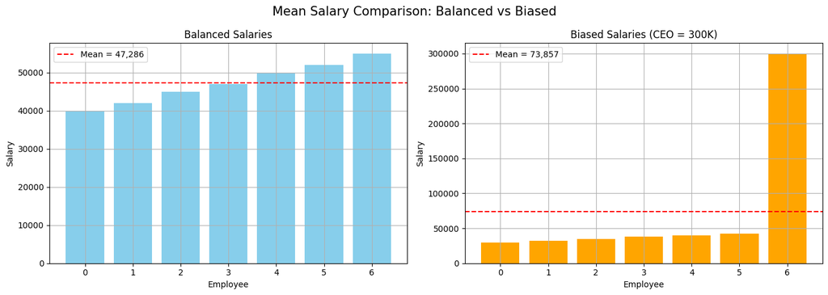

```python
# Plot
fig, axs = plt.subplots(1, 2, figsize=(14, 5))

# Balanced salaries
axs[0].bar(range(len(salaries_balanced)), salaries_balanced, color='skyblue')
axs[0].axhline(mean_bal, color='red', linestyle='--', label=f'Mean = {mean_bal:,.0f}')
axs[0].set_title("Balanced Salaries")
axs[0].set_xlabel("Employee")
axs[0].set_ylabel("Salary")
axs[0].legend()
axs[0].grid(True)

# Biased salaries
axs[1].bar(range(len(salaries_biased)), salaries_biased, color='orange')
axs[1].axhline(mean_bias, color='red', linestyle='--', label=f'Mean = {mean_bias:,.0f}')
axs[1].set_title("Biased Salaries (CEO = 300K)")
axs[1].set_xlabel("Employee")
axs[1].set_ylabel("Salary")
axs[1].legend()
axs[1].grid(True)

plt.suptitle("Mean Salary Comparison: Balanced vs Biased", fontsize=15)
plt.tight_layout()
plt.show()
```

- 2 Median
  - Median wo value hoti hai jo data ko half mein divide karti hai.
  - Agar data sorted hai toh:
    - Odd number of data points: Median = Middle element
    - Even number of data points: Median = Average of two middle elements
- Odd Number Example

[figure not shown]

```python
data = [4, 7, 2, 9, 12]
df = pd.DataFrame(data, columns=["Value"])
df
```

|  | Value |
| --- | --- |
| 0 | 4 |
| 1 | 7 |
| 2 | 2 |
| 3 | 9 |
| 4 | 12 |

```python
data = sorted(data)
data
```

```
[2, 4, 7, 9, 12]
```

```python
int(len(data) / 2)
```

```
2
```

```python
data[int(len(data) / 2)]
```

```
7
```

```python
# with direct pandas
df.median()
```

```
Value    7.0
dtype: float64
```

- Even Number Example

[figure not shown]

```python
data = [4,7,2,12,6,10]
df = pd.DataFrame(data,columns=["Value"])
df
```

|  | Value |
| --- | --- |
| 0 | 4 |
| 1 | 7 |
| 2 | 2 |
| 3 | 12 |
| 4 | 6 |
| 5 | 10 |

```python
data = sorted(data)
data
```

```
[2, 4, 6, 7, 10, 12]
```

```python
len(data)
```

```
6
```

```python
if len(data) % 2 == 0:
    #index
    upper = int(len(data)/2) -1
    lower = int(len(data)/2)
    print('Index',upper,lower)
    print('Value',data[upper],data[lower])
    print("Median",(data[upper] + data[lower]) / 2)
```

```
Index 2 3
Value 6 7
Median 6.5
```

```python
# with direct pandas
df.median()
```

```
Value    6.5
dtype: float64
```

- Median for Group Data (if Data Points Sum (N) are Even)

[figure not shown]

```python
class_ = ["0-5","5-10","10-15"]
f = [3,4,3]
df = pd.DataFrame({"class":class_,"f":f})
df
```

|  | class | f |
| --- | --- | --- |
| 0 | 0-5 | 3 |
| 1 | 5-10 | 4 |
| 2 | 10-15 | 3 |

```python
cm = [f[0]]
for i in f[1:]:
    cm.append(cm[-1]+i)
cm
```

```
[3, 7, 10]
```

```python
df['cm'] = cm
df
```

|  | class | f | cm |
| --- | --- | --- | --- |
| 0 | 0-5 | 3 | 3 |
| 1 | 5-10 | 4 | 7 |
| 2 | 10-15 | 3 | 10 |

```python
# direct in pandas
df["f"].cumsum()
```

```
0     3
1     7
2    10
Name: f, dtype: int64
```

```python
# find n

c_sum = 0
for i in f:
    c_sum += i
N = c_sum
print(N)
```

```
10
```

```python
df
```

|  | class | f | cm |
| --- | --- | --- | --- |
| 0 | 0-5 | 3 | 3 |
| 1 | 5-10 | 4 | 7 |
| 2 | 10-15 | 3 | 10 |

```python
cm
```

```
[3, 7, 10]
```

```python
# find F
F = cm[int(len(cm) / 2) - 1]
F
```

```
3
```

```python
# find f
f = f[int(len(f) / 2)]
f
```

```
4
```

```python
# class width
class_[int(len(class_) / 2)]
```

```
'5-10'
```

```python
class_[int(len(class_) / 2)].split('-')
```

```
['5', '10']
```

```python
# change to int
[int(i) for i in class_[int(len(class_) / 2)].split('-')]
```

```
[5, 10]
```

```python
lower = min([int(i) for i in class_[int(len(class_) / 2)].split('-')])
upper = max([int(i) for i in class_[int(len(class_) / 2)].split('-')])
print(upper,lower)
```

```
10 5
```

```python
# find h
h = upper - lower
h
```

```
5
```

```python
# find L
L = lower
L
```

```
5
```

```python
# formulae
Median = L + ((N/2 - F) / f) * h
Median
```

```
7.5
```

- Median for Group Data (if Data Points Sum (N) are Odd)

[figure not shown]

```python
class_ = ["0-10","10-20","20-30","30-40"]
f = [2,3,3,1]
df = pd.DataFrame({"class":class_,"f":f})
df
```

|  | class | f |
| --- | --- | --- |
| 0 | 0-10 | 2 |
| 1 | 10-20 | 3 |
| 2 | 20-30 | 3 |
| 3 | 30-40 | 1 |

```python
cm = [f[0]]
for i in f[1:]:
    cm.append(cm[-1]+i)
cm
```

```
[2, 5, 8, 9]
```

```python
df['cm'] = cm
df
```

|  | class | f | cm |
| --- | --- | --- | --- |
| 0 | 0-10 | 2 | 2 |
| 1 | 10-20 | 3 | 5 |
| 2 | 20-30 | 3 | 8 |
| 3 | 30-40 | 1 | 9 |

```python
# with pandas
df['f'].cumsum()
```

```
0    2
1    5
2    8
3    9
Name: f, dtype: int64
```

```python
# find median class
N = 0
for i in f:
    N += i
N
```

```
9
```

```python
if N %2 == 1:
    print(N/2)

    # find middle class
    for index,i in enumerate(cm):
        if i >= N/2:
            print(i,index)
            break
```

```
4.5
5 1
```

```python
index
```

```
1
```

```python
# find f
f = f[index]
f
```

```
3
```

```python
# find F
F = cm[index-1]
F
```

```
2
```

```python
# find upper and lower class
class_[index]
```

```
'10-20'
```

```python
# convert into int
mid_class = [int(i) for i in class_[index].split("-")]
mid_class
```

```
[10, 20]
```

```python
lower = min(mid_class)
upper = max(mid_class)
```

```python
# find h
h = upper - lower
h
```

```
10
```

```python
L = lower
L
```

```
10
```

```python
# find median
L + (N/2 - F)/f * h
```

```
18.333333333333336
```

## -> Median Examples

- Use of Median
  - Median sahi salary level dikhata hai ya nahi jab data balanced ho ya biased (CEO outlier ho).
  - Median = middle value (jab data ko sort kar do)
  - Odd count: beech wali value
  - Even count: 2 beech wali ka average

```python
# Balanced salaries: sab qareeb qareeb
salaries_balanced = [40000, 42000, 45000, 47000, 50000, 52000, 55000]

# Biased salaries: CEO ki salary outlier hai
salaries_biased = [30000, 32000, 35000, 38000, 40000, 42000, 300000]
```

```python
# Median calculate karo
median_bal = np.median(salaries_balanced)
median_bias = np.median(salaries_biased)

print(median_bal,median_bias)
```

```
47000.0 38000.0
```

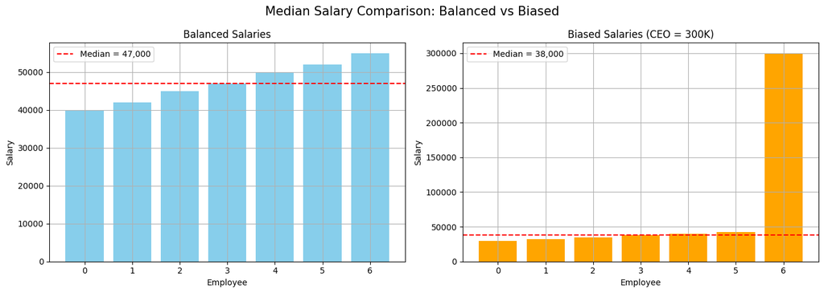

```python
# Plotting
fig, axs = plt.subplots(1, 2, figsize=(14, 5))

# Balanced
axs[0].bar(range(len(salaries_balanced)), salaries_balanced, color='skyblue')
axs[0].axhline(median_bal, color='red', linestyle='--', label=f'Median = {median_bal:,.0f}')
axs[0].set_title("Balanced Salaries")
axs[0].set_xlabel("Employee")
axs[0].set_ylabel("Salary")
axs[0].legend()
axs[0].grid(True)

# Biased
axs[1].bar(range(len(salaries_biased)), salaries_biased, color='orange')
axs[1].axhline(median_bias, color='red', linestyle='--', label=f'Median = {median_bias:,.0f}')
axs[1].set_title("Biased Salaries (CEO = 300K)")
axs[1].set_xlabel("Employee")
axs[1].set_ylabel("Salary")
axs[1].legend()
axs[1].grid(True)

plt.suptitle("Median Salary Comparison: Balanced vs Biased", fontsize=15)
plt.tight_layout()
plt.show()
```

Compare

[output not shown]

| Comparison Point | Mean | Median |
| --- | --- | --- |
| **Outlier se effect** | ⚠️ Zyada hota hai | ✅ Safe rehta hai |
| **Skewed data mein kaam?** | ❌ Mislead karta hai | ✅ Real picture deta hai |
| **Balanced data mein?** | ✅ Accurate center | ✅ Accurate center |
| **Kya batata hai?** | Total ka average (influenced by extremes) | Central position (independent of extremes) |

Kab Mean aur Median Use Karna Chahiye?

| Situation / Condition | Use **Mean** ✅ | Use **Median** ✅ | Reason / Explanation |
| --- | --- | --- | --- |
| ✅ Data **balanced ho** (no outliers) | ✅ Haan | ✅ Haan | Dono sahi kaam karte hain kyunki data fair hai |
| ❌ Data mein **outliers ho** (extreme values) | ❌ Nahi | ✅ Median Best | Mean outlier ki wajah se mislead karega, median safe hoti hai |
| ❌ Data **skewed** ho (uneven distribution) | ❌ Nahi | ✅ Haan | Median original center dikhata hai, mean distort ho jata hai |
| ✅ Normal Distribution (Bell curve) | ✅ Best | ✅ Workable | Mean aur median close hotay hain |
| ✅ Data ka **total ya average** important ho | ✅ Mean | ❌ Nahi | Jaise total salary / marks ka average chahiye |
| ✅ Income, house price, age jaise **real-world biased data** | ❌ Nahi | ✅ Haan | Real-world data mein outliers hote hain, median zyada reliable hoti hai |
| ✅ Machine Learning model ke liye **standardization** | ✅ Mean + Std | ❌ Nahi | Mean zaroori hota hai (x - mean) standardization ke liye |
| ✅ Missing value fill karna ho | ❌ Nahi (if skewed) | ✅ Haan | Median reliable hoti hai jab data skewed ya incomplete ho |
| ✅ Categorical ya ordinal data (e.g., survey ranks) | ❌ Nahi | ✅ Median | Mean meaningful nahi hota, median middle rank dikhata hai |

- 3 Mode
  - Mode wo value hoti hai jo sabse zyada baar repeat hoti hai data mein.
- Example 1: (Ungroup)

```python
data = [4, 7, 7, 2, 9]
data
```

```
[4, 7, 7, 2, 9]
```

```
➡️ Total values = 5 → Odd
```

```python
tmp = []
for i in data:
    if i not in tmp:
        tmp.append(i)
        print(i,"->",data.count(i))
```

```
4 -> 1
7 -> 2
2 -> 1
9 -> 1
```

```
➡️ Mode = 7
```

- Example 2: (Ungroup)

```python
data = [3, 5, 2, 3, 8, 2]
tmp = []
for i in data:
    if i not in tmp:
        tmp.append(i)
        print(i,"->",data.count(i))
```

```
3 -> 2
5 -> 1
2 -> 2
8 -> 1
```

```
➡️ Mode = 3 and 2
Type (Bimodal)
```

- Example 3: (Ungroup)

```python
data = [1, 2, 3, 4, 5]
tmp = []
for i in data:
    if i not in tmp:
        tmp.append(i)
        print(i,"->",data.count(i))
```

```
1 -> 1
2 -> 1
3 -> 1
4 -> 1
5 -> 1
```

```
➡️ No Mode
```

```python
data = [1, 1, 2, 2, 3, 3]
tmp = []
for i in data:
    if i not in tmp:
        tmp.append(i)
        print(i,"->",data.count(i))
```

```
1 -> 2
2 -> 2
3 -> 2
```

```
➡️ Mode = 1,2,3
Type (Multimodal)
```

- Mode For Group Data

[figure not shown]

```python
class_ = ["0-10","10-20","20-30","30-40","40-50"]
f = [4,7,12,5,2]
df = pd.DataFrame({"class":class_,"f":f})
df
```

|  | class | f |
| --- | --- | --- |
| 0 | 0-10 | 4 |
| 1 | 10-20 | 7 |
| 2 | 20-30 | 12 |
| 3 | 30-40 | 5 |
| 4 | 40-50 | 2 |

```python
# find high frequency class
tmp = 0
INDEX = 0
for index,i in enumerate(f):
    if i > tmp:
        tmp = i
        INDEX = index
        print(i)
```

```
4
7
12
```

```python
print(INDEX,tmp)
```

```
2 12
```

```python
f[INDEX]
```

```
12
```

```python
class_[INDEX]
```

```
'20-30'
```

```python
mid_class = [int(i) for i in class_[INDEX].split('-')]
lower = min(mid_class)
upper = max(mid_class)
```

```python
L = lower
f1 = f[INDEX]
f0 = f[INDEX-1]
f2 = f[INDEX+1]
h = upper - lower
```

```python
Mode = L + ( (f1 - f0) / (2 * f1 - f0 - f2) ) * h
Mode
```

```
24.166666666666668
```

| **Measure** | **Ungrouped Equation** | **Grouped Equation** | **Odd/Even Note** | **Sort Required?** | **Cumulative Frequency?** |
| --- | --- | --- | --- | --- | --- |
| **Mean** | Mean = (Σx) / n | Mean = (Σf·x) / Σf | No effect | ❌ Nahi | ❌ Nahi |
| **Median** | Odd: x<sub>(n+1)/2</sub> Even: (x<sub>n/2</sub> + x<sub>(n/2)+1</sub>) / 2 | Median = L + ((N/2 - F) / f) × h | N/2 se class locate karni hoti hai | ✅ Haan | ✅ Haan (Grouped only) |
| **Mode** | Most repeated value | Mode = L + ((f₁ - f₀) / (2f₁ - f₀ - f₂)) × h | No effect | ❌ Nahi | ❌ Nahi |

## -> Mode Examples

- Mode wo value hoti hai jo sabse zyada baar repeat hoti hai data mein.
  - Ek dataset mein 1 mode ho sakta hai (unimodal)
  - Ya zyada (bimodal, multimodal)
  - Ya kabhi koi bhi repeat na ho to no mode

```python
grades = ['B', 'A', 'C', 'B', 'B', 'A', 'C', 'B']
grades
```

```
['B', 'A', 'C', 'B', 'B', 'A', 'C', 'B']
```

- Mode = 'B' (kyunki 4 baar aayi)

```python
shoe_sizes = [7, 8, 8, 9, 7, 8, 10, 9, 8]
shoe_sizes
```

```
[7, 8, 8, 9, 7, 8, 10, 9, 8]
```

- Mode = 8 (sabse zyada logon ka same size)

```python
import matplotlib.pyplot as plt
from collections import Counter
import statistics
```

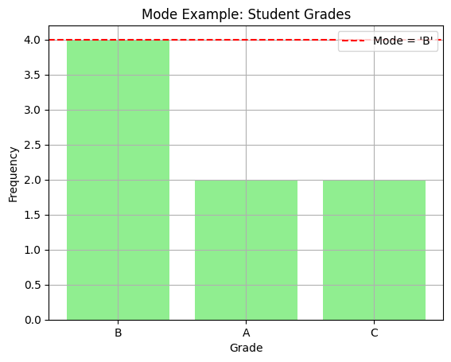

```python
# Example dataset
grades = ['B', 'A', 'C', 'B', 'B', 'A', 'C', 'B']

# Count frequency
count = Counter(grades)
labels, values = zip(*count.items())

# Mode calculate
mode_val = statistics.mode(grades)

# Plot
plt.bar(labels, values, color='lightgreen')
plt.axhline(y=values[labels.index(mode_val)], color='red', linestyle='--', label=f"Mode = '{mode_val}'")
plt.title("Mode Example: Student Grades")
plt.xlabel("Grade")
plt.ylabel("Frequency")
plt.legend()
plt.grid()
plt.show()
```

| Feature | Mean | Median | Mode |
| --- | --- | --- | --- |
| Kya batata hai? | Average value | Middle value | Most frequent value |
| Outlier sensitive? | ✅ Yes | ❌ No | ❌ No |
| Categorical pe kaam? | ❌ Nahi | ❌ Limited | ✅ Perfect |
| Numerical data? | ✅ Yes | ✅ Yes | ✅ Yes |

| Condition / Situation | ✅ Use Mean | ✅ Use Median | ✅ Use Mode | 🔎 Explanation |
| --- | --- | --- | --- | --- |
| 📈 **Balanced numerical data** | ✅ Yes | ✅ Yes | ❌ Rarely | Mean aur Median dono accurate center dikhate hain |
| ⚠️ **Data mein outliers hon (e.g. CEO salary)** | ❌ No | ✅ Yes | ❌ Maybe | Median zyada reliable hoti hai |
| 🔀 **Skewed (uneven) data** | ❌ No | ✅ Yes | ❌ No | Median real center show karta hai |
| 📉 **Normal (bell-shaped) distribution** | ✅ Yes | ✅ Yes | ✅ Maybe | Sab close hotay hain — koi bhi kaam kar sakta hai |
| 🔡 **Categorical data (e.g. Shirt, Pant)** | ❌ No | ❌ No | ✅ Yes | Mode hi kaam karta hai — most frequent value |
| 🧩 **Ordinal data (e.g. Poor, Good, Excellent)** | ❌ No | ✅ Yes | ✅ Yes | Median + Mode dono useful — average rank ya most frequent |
| 🧼 **Missing value fill — numerical balanced** | ✅ Yes | ✅ Yes | ❌ No | Mean ya Median use hoti hain |
| 🧼 **Missing value fill — skewed/outlier data** | ❌ No | ✅ Yes | ❌ No | Median safe hoti hai from distortion |
| 🧼 **Missing value fill — categorical** | ❌ No | ❌ No | ✅ Yes | Mode sabse zyada common value fill karta hai |
| 🧮 **Data center chahiye (center of tendency)** | ✅ Yes | ✅ Yes | ❌ No | Center ke liye mean/median better hotay hain |
| 📊 **Data summary (quick idea)** | ✅ Yes | ✅ Yes | ✅ Yes | Teeno ka use ek sath bhi hota hai |
| 🤖 **ML: Standardization (x - mean / std)** | ✅ Required | ❌ No | ❌ No | Mean required hota hai Standard Scaler ke liye |
| 🤖 **ML: Robust Scaler / Skewed Data** | ❌ No | ✅ Yes | ❌ No | Median based scaling zyada stable hoti hai |
| 🧠 **User behavior ya product trend analysis** | ❌ No | ❌ No | ✅ Yes | Mode se most common item find hota hai |